# Session 3+4: Introduction into R and Econometrics

2023-07-17

## Overview of QEC9X01

- Session 1: Oligopolistic Competition Refresher
- Session 2: Oligopolistic Competition Refresher (cont.)
- *Session 3: Introduction into R and Econometrics*
- *Session 4: Introduction into R and Econometrics (cont.)*
- Session 5: Estimation of Demand for Homogenous Goods
- Session 6: Identification of Conduct and Collusion
- Session 7: Econometrics Tutorial
- Session 8: Product Differentiation, Multinomial Logit
- Session 9: Differentiated Demand Workshop
- Session 10: Market Structure and Entry
- Session 11: Merger analysis
- Session 12: Merger analysis - Empirical tutorial in R

## A few words about me: CV

- Associate Professor MINES Paris-PSL University.
- Before: Marie-Curie Fellow (AgreenSkills+) and Post-Doctoral Researcher at the Toulouse School of Economics (TSE)
- PhD: Duesseldorf Institute of Competition Economics (DICE)

## My Research

*Field*: analysis of firm size, market power, competition, and public policies at different levels of supply chains.

*Methodology*: Structural Models for causal inference using economic theory, empirical methods, and data.

*Research Topics*:

- How does size + market power affect prices and variety?
- What is the damage from illegal collusive price fixing?
- How much of a cost increase (e.g., taxes) do firms pass-on to their consumers?

## Selected Academic Articles

- **Vertical Restraints, Pass-Through, and Market Definition: Evidence from Grocery Retailing**, *International Journal of Industrial Organization* 74, 2021.
- **The Effect of Mergers on Retail Prices: Evidence from Germany**, *Journal of Industrial Economics* 69, 3
- **Upstream Collusion with Vertical Restraints: Anatomy of the German Coffee Cartel**, joint with E. Holler, *International Journal of Industrial Organization* 84, 2022

## Newspaper, Blogs, Policy,

*Newspaper Articles*

- **Minimum retail prices do not increase sustainability**, *Frankfurter Allgemeine Zeitung (FAZ)*, Feb 4, 2022, [Link](https://drive.google.com/file/d/1CSVcCWSf6zMR16zvU88viYqBk0UKV88F/view)

*Blogs*

- **[A Bad Apple in the Based. Market Power in Digital Markets illustrated by the Apple-Epic Case]**, *Kluwer Competition Law Blog*, Feb 17, 2022, [Link](https://competitionlawblog.kluwercompetitionlaw.com/2022/02/17/a-bad-apple-in-the-basket-market-power-in-digital-markets-illustrated-by-the-epic-apple-case/)

Policy Papers (in German)

- Determination of Buyer Power in Grocery Retailing: Theoretical Foundations and Empirical Assessment
- Competition (Problems) in Food Retailing

## Other Services

*Scientific reviewer* in journals, such as

- International Journal of Industrial Organization;
- American Journal of Agricultural Economics;
- some others

… as *practitioner*

- Research Assistant for the German Monopolies Commission
- Economic expert for cartel offices and cartel victims in cases of (i) buyer power and (ii) cartel overcharges

… as *presenter* to - DG comp of the EC - cartel offices in Germany, Norway, and Chile

## What we do in Session 3+4

- Part A: Introduction into R and RStudio
- Part B: Causality using economic and empirical models
- Part C: Refresher of Econometrics
  - mainly linear regression concept, OLS, omitted variables
- Part D: Refresher of Econometrics
  - mainly endogeneity, instrument variables, 2SLS

*Brilliant minds expressed their scepticism regarding statistics*

- **There are three kinds of lies: lies, damned lies, and statistics** (popularized by Mark Twain)
- **The only statistics you can trust are those you falsified yourself** (attributed to Whinston Churchill)

One reason may lie in the abuse of statistics…

- **Torture the data until it confesses** (Mancur Olson)

… another in the difficulty of using statistics appropriately

- **The economy is a miserable experimental design** (R. E. Lucas)

In this class, we learn the proper use of statistics in economics

## What is improper use of statistics?

Indeed, we all do honest mistakes due to

- time pressure (deadlines for bachelor, master, PhD)
- loosing track in the **garden of forking paths** (A. Gelman)

Sometimes there are illegitimate attempts for fame

- **p-hacking**: torturing the data until we get the result we want
- **HARKing**: making your *H*ypothesis *A*fter *R*esult *K*nown
- **fraud**: faking the data

… potentially caused by publication bias or biased employer

## This led to replication crisis: psychology

Only 23-33% of studies in leading Psychology journal replicated:

- [Group Author: Open Science Collaboration](https://mfr.osf.io/render?url=https://osf.io/jq7v6/?action=download%26mode=render%3E)
- [Link to article in Nature](https://www.nature.com/articles/nature.2015.17433)

Standard theory of social priming not at all reproducible:

- Students exposed to senior-connotated words walk slower, warm coffee makes people feel warmer towards others, people exposed to the word money are more selfish, etc
- Some claim that none of the studies in Kahnemann’s thinking fast and slow would replicate (e.g., framing)
- [Link to article in Nature](https://www.nature.com/articles/d41586-019-03755-2)

## This led to replication crisis: medicine

Only 11-30% of cancer studies could be replicated:

- [Link to article in Science](https://www.sciencemag.org/news/2018/07/plan-replicate-50-high-impact-cancer-papers-shrinks-just-18)
- [Link to article in Nature](https://www.nature.com/articles/483531a)

J. Ioannidis’ drastic conclusion: Most Clinical Research Not Useful

- [Why Most Clinical Research Is Not Useful](https://journals.plos.org/plosmedicine/article?id=10.1371/journal.pmed.1002049)

## This led to replication crisis: economics

60-70% of studies in major journals could be replicated:

- [Link 1 to article in Science](https://science.sciencemag.org/content/351/6280/1433)
- [Link 2 to article in Science](https://www.sciencemag.org/news/2016/03/about-40-economics-experiments-fail-replication-survey)

Why is that?

- Combining economic theory, rigorous econometrics, and good data? Aka Structural Econometrics?
- Using Stata, Python, and R for reproducible research?
- You will both learn in this class!

## Learning objectives of Session 3+4 Part A

- Understand how to use GitHub, R, and RStudio
  - for reproducible research
  - with transparent path to final results
  - using version control for error management
- Become confident to use them (no rocket science!)
- Understand why we need econometrics: to have causal effects instead of (potentially spurious) simple correlations
- Revisit the standard tools of econometrics: OLS, 2SLS
- Apply linear regressions in R without and with endogeneity

## Introduction into R and RStudio

## Impressive growth of R

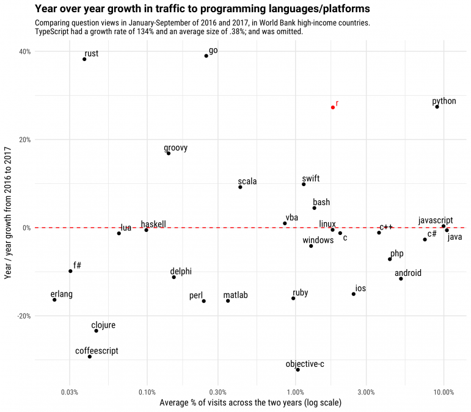

https://stackoverflow.blog/2017/10/10/impressive-growth-r/

## Some basics in R…

To be able to use R, we need to understand:

- Surface of R and RStudio
- Packages
- Data (frames, import, export, missings)
- Summary statistics and graphs

… which we learn in this class.

## Before using R and RStudio

R is a free software (GNU license)

- from: http://www.r-project.org

works best in combination with RStudio

- from: https://posit.co/download/rstudio-desktop

Sign up for Github (for version control): https://github.com/

- and download Github desktop: https://desktop.github.com/

## Useful links

Some introductory classes: Using R for Introductory Econometrics: - http://www.urfie.net/

If you need help:

- Search engine: keyword + rstats
- Forums:
  - http://stats.stackexchange.com/questions/tagged/R
  - http://stackoverflow.com/questions/tagged/r

## Github for content + version control

Once you have installed everything, and signed up for the necessary:

- Go to https://github.com/DennisRickert/IOIntroduction,
  - click on ‘fork’, then ‘fork’ again.
  - then ‘code’, then ‘Open with Github desktop’
- Open RStudio on your computer, click on ‘new project’, then browse to the folder that you just cloned the git repo into in Windows
- probably: C:/Users/Username/Documents/GitHub/IOIntroduction

## Save your work in github

In RStudio, once you have opened your project:

- Click on ‘file’, ‘new file’, ‘Rmarkdown’, ‘PDF’, and save it (‘tutorial1’)
- Click on ‘knit’
- RMarkdown is a great way to have your report text and econometrics code in the same file

## Trying out Git

In RStudio:

- Head over to git on the top right hand side, select files you’d like to commit, click ‘commit’, add a message (e.g. ‘first commit’), and then click ‘commit’, then ‘push’
- Git is a version control system that you can use to roll back to any version of your work
- Commit frequently
- You may want to add a branch, perhaps called ‘local’, so that you are not working on the ‘master’ (production) version You can have a look at your latest commit and push on github.com

## Surface of RStudio (using R)

The surface of RStudio consists of four windows

- Script file (upper left)
  - write reproducible code
- Console (lower left)
  - output is shown
- Work space (upper right): environment, history, …
  - mainly shows your variables and data
- Auxiliary (lower right): files, plots, packages, …
  - nice help function but otw rarely used

## Screenshot of surface of R Studio

[figure not shown]

## Console = similar to calculator:

Simple operations

```r
2+4
```

```
## [1] 6
```

```r
5*3
```

```
## [1] 15
```

```r
3^4
```

```
## [1] 81
```

## Console = similar to calculator:

creating a vector of 1 row and 5 columns.

```r
c(1,2,3,4,5)
```

```
## [1] 1 2 3 4 5
```

```r
rbind(1:5)
```

```
##      [,1] [,2] [,3] [,4] [,5]
## [1,]    1    2    3    4    5
```

## Console = similar to calculator:

creating a vector of 5 rows and 1 column

```r
cbind(1:5)
```

```
##      [,1]
## [1,]    1
## [2,]    2
## [3,]    3
## [4,]    4
## [5,]    5
```

## Console = similar to calculator:

creating matrices. Alternative is function matrix()

```r
cbind(1:5,1:5)
```

```
##      [,1] [,2]
## [1,]    1    1
## [2,]    2    2
## [3,]    3    3
## [4,]    4    4
## [5,]    5    5
```

```r
rbind(1:5,1:5)
```

```
##      [,1] [,2] [,3] [,4] [,5]
## [1,]    1    2    3    4    5
## [2,]    1    2    3    4    5
```

## Practical Excercise

1/ Type in calculator operations in console

## Functions

| Command | Description |
| --- | --- |
| sqrt(x) | square root of value x |
| abs(x) | absolute value of x |
| exp(x) | exponential of x |
| log(x) | natural logarithm of ln(x) |
| round(x,s) | round x to s digits after decimal point |

## Practical Excercise

2/ Type in functions with x=5.34, s=1 in console

## R scripts

## However, we prefer to use R scripts:

- Do not type commands in console, collect in them in R-scripts
- R-scripts: text file with file extension: .R
- Advantages:
  - Transparency
  - Documentation
  - Easy to correct mistakes
  - Reproducibility
  - You can run the code with one click when data changes

## Working with R scripts

- You can run scripts all at once, line-by-line, or in sections
  - Mouse click: -> run (all or selection)
  - Menu: code -> run (all or selection)
  - ctrl + enter (all or selection)
- You should comment the scripts.
  - Each line starting with # will be ignored by R
  - Helps for documentation and to remember why you did what (for yourself and others)

```r
# This is a comment for 3*8
3*8
```

```
## [1] 24
```

## Practical Excercise

3/ Create new R script

- File -> New File -> R Script
- ctrl + shift + n

## Variables

## Variables: what are they?

- Variables are similar to objects in other programs
- Variables can be populated with a variety of content, e.g.,
  - Numbers
  - Vectors
  - Matrices
  - Data sets
  - Results from econometric estimations
  - …

## Variables: create + operate

Create a new variable by assigning a value to it using “<-”

```r
# Create vector x from 1 to 5 without printing
x <- c(1:5)
```

Operate with variables

```r
# Create vector y = x+2
y <- x + 2

# Print y
y
```

```
## [1] 3 4 5 6 7
```

- RStudio shows the variable in the “Environment” panel.
- Print variable: type variable name and hit enter.

## Special functions for variables

| Command | Description |
| --- | --- |
| x[i] | i-th value within vector x |
| length(x) | length of vector x (number of elements) |
| min(x) | minimum of vector x (smallest element) |
| max(x) | maximum of vector x (largest element) |
| sum(x) | sum of elements in vector x |
| mean(x) | mean of elements in vector x |
| sort(x) | sort elements in vector x (from lowest to largest) |
| t(x) | transpose vector x (exchange columns and rows) |

## Functions also work with vector x

```r
# Create vector x from 1 to 5.
x <- c(1:5)

# Show output of square root of x
sqrt(x)
```

```
## [1] 1.000000 1.414214 1.732051 2.000000 2.236068
```

Similarly, we can type:

- abs(x)
- exp(x)
- log(x)
- round(x,s)

## Data

## Create data (using data.frame)

- Data: collection of **vectors** into columns and rows
  - just like matrices and tables
- **Vectors** often are our variables c();
  - the first row is the variable name x1,x2, …
- Function data.frame(x1,x2,…)
  - creates a data set consisting of vectors x1,x2,…
- Extract vector x1 from data frame df
  - e.g., df$x1

## Create data: Application

```r
# create fake vectors
year <- c(2001:2010)
revenues <- sample.int(100, 10)
costs <- sample.int(10, 10)

# gather fake vectors in data frame
my_df <- data.frame(year,revenues,costs)

# save data
save(my_df, file="~/my_df.Rdata")

# view data
my_df
```

```
##    year revenues costs
## 1  2001       72     6
## 2  2002       45     7
## 3  2003       59     9
## 4  2004       42     1
## 5  2005       22    10
## 6  2006       91     5
## 7  2007       64     3
## 8  2008       49     2
## 9  2009       69     8
## 10 2010       16     4
```

## Create data: Application contd.

```r
# extract vector / variable name from data frame
my_df$revenues
```

```
##  [1] 72 45 59 42 22 91 64 49 69 16
```

```r
# simulate new revenue and store as new variable
new_revenue = 5 + my_df$revenues
new_revenue
```

```
##  [1] 77 50 64 47 27 96 69 54 74 21
```

```r
# add variable to data frame
my_df$new_revenue <- new_revenue

# add variable directly to data frame
my_df$profit <- my_df$revenues - my_df$cost
```

## Useful functions for data frames (df)

| Command | Description |
| --- | --- |
| names(df) | variable names |
| nrow(df) | number of rows (i.e., observations) |
| ncol(df) | number of columns (i.e., variable names) |
| head(df) | first 6 rows of data frame |
| tail(df) | last 6 rows of data frame |

## Brief digression: Packages

We use the package *rio* to import data

- Packages extend the functionality of R
- To use the package *rio* (or others):
  - Download once per computer by install.packages(“rio”)
  - Activate once per session and script using library(“rio”)

We will also need the various other packages in “0 starthere.R”, so please install and load them.

## Import data

- R can import several types of data sets: xls, csv, txt, .dta, …
- *rio* can detect the data type automatically
- We use the command import from the package *rio*

```r
# import data set using command import from package rio
# install.packages("rio") if needed
library("rio")
df <- import("~/my_df.Rdata")
```

## Practical Excercise

5/ Import data and store in data frame df

## Missing Data (na = no available)

- mean(x1, na.rm=true)
  - drop missing values from calculation of mean
- is.na(x1)
  - Check if missing values (na) exist in your data
- na.omit(df)
  - Create new data frame with all missing values (na) omitted

## Graphs

## Graphs

> *“The simple graph has brought more information to the data analyst’s mind than any other device*” John Tukey
> > - Graphs are the most important tool for data analysis!!!
> > - We use ggplot2, with gg standing for “grammar of graphics”
> > - This shows the philosophy of the package
> > - Google, Microsoft, New York Times create graphs like this
> > - Cheatsheet:
> >   - Help -> Cheatsheets -> Data visualization with ggplot2

## Structure of the command ggplot

- Create new graph by using ggplot()
- Geometrical objects (“Geoms”) added using symbol “+”
- Each graph consists of geometrical objects (Geoms)
  - Lines: geom_line()
  - Dots: geom_point()
  - … (see “Cheatsheet”)
- Each Geom requires
  - A dataset containing our variables of interest
  - A mapping of the variables with the graphical elements (aesthetics)
    - x: x-axis
    - y: y-axis

## Example Graph

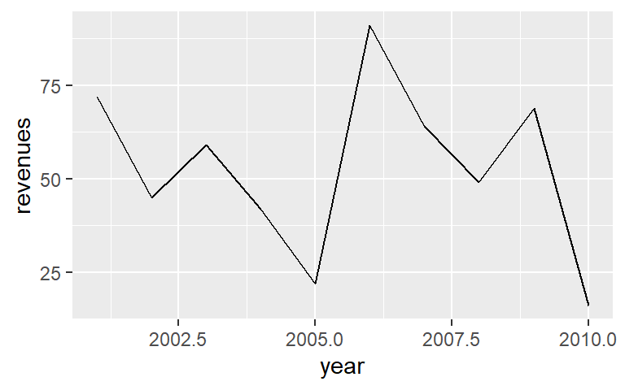

```r
library(ggplot2)
ggplot() +
  geom_line(data=my_df,
            mapping=aes(x=year, y=revenues))
```

Revenues of the 10 years from 2001 through 2010 lie between 16 and 91 with an average of 52.9

## Practical Excercise

7/ Create graph using df